# Recognizing Slips of the Tongue With Kaldi ASR

Author:  
Gaynora van Dommelen  
Supervisor:  
R. Ossewaarde  
RESEARCH SEMESTER  
TICT-OVRS-22

## Content

1. Create project folder
2. Gather data
3. Transform data
4. Move data to digits folder
5. Analyze test data
6. Acoustic data
7. Language data
8. Finalizing setup
9. Model evaluation
10. Recognizing speech errors

IMPORTING PACKAGES

```python
import os
from os.path import isdir, join, dirname
import pandas as pd
import numpy as np
from scipy import signal
import matplotlib.pyplot as plt
import librosa
import librosa.display
import ipywidgets as wg
from IPython.display import display, Audio
import os
from typing import List, Callable, Tuple
from scipy.fftpack import fft, ifft
from spectrum import lpc
import matplotlib.transforms as mtransforms
from sklearn import metrics
import warnings
from src.file_frame import update_file_frame, get_samples
from src.sample import get_time_samples
from src.plot import plot_raw_wave, plot_fig, plot_spectrogram, plot_windowed_samples, plot_magnitude_spectrum
from dotenv import load_dotenv
load_dotenv()
main_dir = os.getenv("DIGITSPATH")
warnings.filterwarnings('ignore')
```

## Speech Errors

1. $s_{1} : v\rightarrow p$ This person uses a *p* instead of a *v* consonant. So that the words: 'seven [s eh v ah n]' and 'five [f ay v]' now become 'sepen [s eh p ah n] ' and 'fipe [f ay p]'.

   > Do note that in this dataset the word 'fipe' does not represent anything, but closely resembles the word 'vipe' which in English is a word. So while this could give a low confidence score for this dataset, in a model trained on data where similar sounding words to 'fipe' exist, this doesn't necessarily happen.
2. $s_{2} : w_{1}\rightarrow w_{2}$ This person represents doubt. It is a fabrication of the situation where a sound is made belonging to another number while the intention and the end result is another digit, resulting in a combination of two digits. So, the words: 'one [w ah n]' $\rightarrow$ 'tw'one [t uw w ah n]', 'five [f ay v]' $\rightarrow$ 'fou'five [f ao f ay v]' and 'nine [n ay n]' $\rightarrow$ 'eigh'nine [ey n ay n]'.

*The transcription for each of these words is the intended word. By using the intended word, the resulting transcription may show low confidence scores because of the uncertainty of combination of sounds.*

To detect these 'anamolies' two approaches will be researched. The first approach involves determining the confidence scores in Kaldi, while the other approach involves using the time bound transcriptions to analyse the differences between the training and test group.

## Step 1. Create project folder

```python
%%bash

cd ../git_workspace/kaldi/egs
[ ! -d digits ] && mkdir digits || echo "folder already exists"
```

## Step 2. Gather data

Start by creating the folders that will contain the data.

In the `digits` folder, create the folder: `digits_audio`. Then, in the `digits_audio` folder, create the folders: `train` and `test`.

```python
%%bash -s "$main_dir"

cd $1;
[ ! -d digits_audio ] && mkdir digits_audio
cd digits_audio
[ ! -d train ] && mkdir train
[ ! -d test ] && mkdir test
tree .
```

```
.
├── test
└── train

2 directories, 0 files
```

TRAIN DATA

We use the Free Spoken Digit Dataset [FSDD](https://github.com/Jakobovski/free-spoken-digit-dataset) as training set. For each of the 6 speakers in the dataset, the digits 0 to 9 were retrieved by running:

```
./src/utils/get_train_data.sh
```

These files are locally stored in the current project folder under `data/train/raw`.

TEST DATA

Two people volunteered to take on the speakers $s_{1}$ and $s_{2}$. Both speakers are male and carry a Dutch accent.

The recordings were made and cut into seperate digits by following the guide left by the makers of the FSDD for adding new data.

These files are locally stores in the current project folder under `data/test/raw`

## Step 3. Transform data

To follow along with the Kaldi tutorial for Dummies, the data will be transformed to form sequences of 3 digits: \_\_\.wav.

To make sure that every digit appears at least once and have files to compare across speakers, we'll create 4 common files for each of the speakers:

`0_1_2.wav`, `3_4_5.wav`, `6_7_8.wav` and `9_0_1.wav`

In total, 10 files for each of the speakers of the train and test set, including the ones previously mentioned.

This is done by running the following commands:

```
./src/utils/transform_data.sh train/raw train/final
./src/utils/transform_data.sh test/raw test/final
```

The newly created files for the train set are stored in the current project folder: `data/train/final`. And the concatenated files for the test set are stored in: `data/test/final`.

## Step 4. Move data to digits folder

After transforming the data, the data is now ready to be added to the Kaldi project folder `digits` for both the test and train set.

```python
%%bash -s "$main_dir"

cp -Rp data/train/final/* $1/digits_audio/train
cp -Rp data/test/final/*  $1/digits_audio/test
```

## Step 5. Analyze test data

Though the files for the test data was created following the descriptions made by the makers of the FSDD set, looking at some of the measures of central tendancy could show whether for example the duration of the audio files is similar to that of the train set.

CREATE DATAFRAME TO EASILY COMPARE/ANALYZE/RETRIEVE FILES

To later analyze, compare and visualize files a `pandas.MultiIndex` will be used:

|  |  |  | samples | duration |
| --- | --- | --- | --- | --- |
| **speaker** | **set** | **filename** |  |  |
| jackson | train | 0_1_2 | [..] | 1.23 |
| ... | ... | ... | ... | ... |

```python
df_files = pd.DataFrame({'speaker':[], 'set':[], 'filename':[], 'samples':[], 'duration':[]})
df_files = df_files.set_index(['speaker', 'set', 'filename'])
df_files
```

|  |  |  | samples | duration |
| --- | --- | --- | --- | --- |
| speaker | set | filename |  |  |

Add each of the audio files for each speaker to the dataframe. Since all audio is sampled at 8kHz, the files will be read and loaded using this sample rate.

```python
update_file_frame(df=df_files)
```

After filling the frame, it can be seen that all speakers and their files have been accounted for.

```python
df_files
```

| speaker | set | filename | samples | duration |
| --- | --- | --- | --- | --- |
| jackson | train | 6_7_8.wav | [0.007354736328125, -0.01104736328125, 0.01040... | 1.607000 |
|  |  | 9_0_1.wav | [-0.009765625, -0.00970458984375, -0.009857177... | 1.764125 |
|  |  | 2_8_3.wav | [-0.0128173828125, -0.01788330078125, 0.008117... | 1.331500 |
|  |  | 0_3_5.wav | [-0.011260986328125, -0.013153076171875, -0.01... | 1.553500 |
|  |  | 7_9_9.wav | [-0.00970458984375, 0.002349853515625, 0.00036... | 1.638875 |
| ... | ... | ... | ... | ... |
| s1 | test | 9_5_6.wav | [0.005706787109375, 0.00518798828125, 0.005340... | 1.821375 |
|  |  | 3_4_5.wav | [0.0035400390625, 0.003509521484375, 0.0044555... | 1.811000 |
|  |  | 8_1_1.wav | [-0.003997802734375, -0.003936767578125, -0.00... | 1.975375 |
|  |  | 0_1_2.wav | [-0.00341796875, -0.000732421875, -0.002319335... | 1.098500 |
|  |  | 5_0_1.wav | [0.00543212890625, 0.005645751953125, 0.005157... | 1.902500 |

80 rows × 2 columns

Comparing the different measures of central tendancy in the duration for the audio files for both the train and test set, shows whether the files are comparable in size.

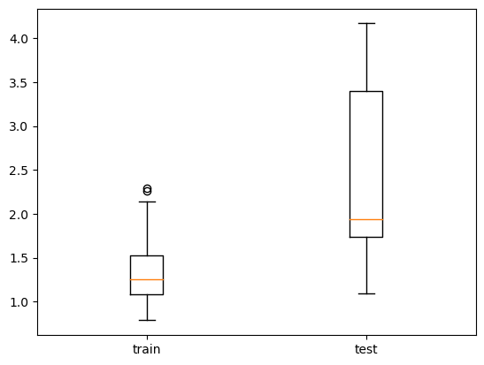

```python
plt.boxplot([df_files.xs('train', level=1)["duration"].values, df_files.xs('test', level=1)["duration"].values], labels=["train", "test"])
plt.show()
```

> As can be seen from the measurements of central tendancy like the min, mean, q3 and max values, the test set has an overall longer duration. One of the causes that could lead to this problem is the cuts that the FSDD script for adding data does to create singleton digit audio files. This could cause pauses to become very short or very long if the speech was not done in a constant manner. This also means that not necessarily both speakers in the test set have such long pauses. To first see whether it is necessary to look at both speakers, first examine the measurements of central tendancy for both speakers.

```python
df_files.loc["s1"].describe()
```

|  | duration |
| --- | --- |
| count | 10.000000 |
| mean | 1.594600 |
| std | 0.318079 |
| min | 1.098500 |
| 25% | 1.325594 |
| 50% | 1.673812 |
| 75% | 1.851281 |
| max | 1.975375 |

> As suggested earlier, it seems like the extreme distribution differences in duration are not caused by both speakers. From the central measurements it can be seen that they closely resemble that of the train set. Therefore, further analyzing the speaker $s_{1}$ is not necessary.

```python
df_files.loc["s2"].describe()
```

|  | duration |
| --- | --- |
| count | 10.000000 |
| mean | 3.278837 |
| std | 0.566486 |
| min | 1.893375 |
| 25% | 3.332000 |
| 50% | 3.396375 |
| 75% | 3.396375 |
| max | 4.168625 |

> This shows that the cause for the shift in central measurements are caused by the audio files of the speaker $s_{2}$. The minimum duration is almost the maximum duration of the train set and most of the files have a longer duration as the max duration of the train set. Therefore further analayzing the files of this speaker is necessary to conform to the speech audio files of the test set.

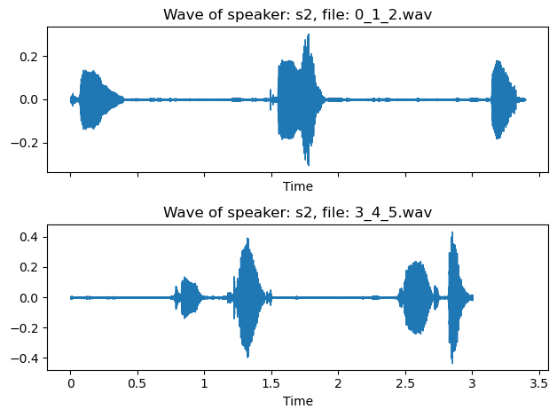

```python
fig, ax = plt.subplots(nrows=2, sharex=True)
librosa.display.waveshow(
    y=np.array(df_files.loc[("s2", "test", "0_1_2.wav"), ('samples')], dtype=np.float32),
    sr=8000,
    ax=ax[0]
)
ax[0].set_title('Wave of speaker: s2, file: 0_1_2.wav')
librosa.display.waveshow(
    y=np.array(df_files.loc[("s2", "test", "3_4_5.wav"), ('samples')], dtype=np.float32),
    sr=8000,
    ax=ax[1]
)
ax[1].set_title('Wave of speaker: s2, file: 3_4_5.wav')
fig.tight_layout()
plt.show()
```

> This shows that a very large portion of each file is probably near silence. Some silences take up to 1 second between spoken digits. To conform to the general duration of the train set, shortening large portions of silence is sufficient.

```python
%%bash -s "$main_dir"

cd $1/digits_audio/test/s2

for file in *;do # Shorten silences longer than 0.5 seconds to 0.3 seconds
    sox $file ${file%".wav"}"_temp.wav" silence -l 1 0.1 1% -1 0.3 1%
    rm $file
    mv ${file%".wav"}"_temp.wav" $file
done
```

Since the files have been changed, the files in the dataframe need to be updated.

```python
update_file_frame(df_files)
```

Now, looking at the distributions of the durations of speech audio files for both the `test` and `train` set:

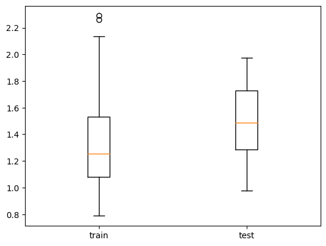

```python
plt.boxplot([df_files.xs('train', level=1)["duration"].values, df_files.xs('test', level=1)["duration"].values], labels=["train", "test"])
plt.show()
```

> The range of duration lays nearer to that of the `train` set and thus is a better representation of input fitting the eventual trained models' data.

## Step 6. Acoustic data

After gathering and transforming the audio data, the next step will be creating text files for, for example the transcription and which files belongs to which speaker.

### Step 6.1 Setup folders for data

In the project folder of `digits` create another folder named `data`. In this folder, again create a `test` and `train` folder.

```python
%%bash -s "$main_dir"

cd $1
[ ! -d data ] && mkdir data
cd data
[ ! -d train ] && mkdir train
[ ! -d test ] && mkdir test
tree
```

```
.
├── test
└── train

2 directories, 0 files
```

The following files need to be created for both the `train` and `test` folder of `data`. However, to prevent duplicating work, all files will first be made for the `train` folder after which the created files will be copy pasted into the `test` folder.

### Step 6.2 Create spk2gender file

As the name suggests this file maps a speaker to their gender. Each speaker (ID) gets mapped to their gender (f/m).

```python
%%bash -s "$main_dir"

cd $1/data/train
test -e spk2gender || cat > spk2gender << EOF
george m
jackson m
lucas m
nicolas m
s1 m
s2 m
theo m
yweweler m
EOF
cd ..;tree
```

```
.
├── test
└── train
    └── spk2gender

2 directories, 1 file
```

### Step 6.3 Create wav.scp file

The `wav.scp` file connects every utterance to an audio file containing the utterance.

```python
%%bash
./src/utils/generate_wav_file.sh
```

### Step 6.4 Create folder `local`

In the data folder create a new folder named `local`.

```python
%%bash -s "$main_dir"

cd $1/data

[ ! -d local ] && mkdir local
tree
```

```
.
├── local
├── test
└── train
    ├── spk2gender
    └── wav.scp

3 directories, 2 files
```

### Step 6.4 Create text, utt2spk and corpus file

The `text` file maps each utterance ID to their transcription, while the corpus keeps all the unique utterances from the transcriptions. Because the corpus contains every unique utterance that is first transcribed in the text file, it is easier to concatenate this to the corpus file during transcribing the audio for the text file. However, the corpus file only appears in the newly made folder in `digits/data/local`. The `utt2spk` file contains the utterance ID along with the transcription of the utterance. Because the utterance ID will be used for all these files it is easier to create this alongside the other files.

```python
%%bash
./src/utils/generate_text_utt2spk_corpus_file.sh
```

### Step 6.5 Sort acoustic files

Kaldi works with sorted audio files. Therefore, all the audio files need to be sorted.

```python
%%bash -s "$main_dir"

cd $1/data/train
for f in *;do
    echo "$(sort $f)" >| $f
done
```

### Step 6.6 Copy files

Now that all the audio files have been created for the `train` set of the data folder, we can copy paste these to the `test` folder of data.

```python
%%bash -s "$main_dir"

cd $1/data/
cp -R train/. test/
tree
```

```
.
├── local
│   └── corpus.txt
├── test
│   ├── spk2gender
│   ├── text
│   ├── utt2spk
│   └── wav.scp
└── train
    ├── spk2gender
    ├── text
    ├── utt2spk
    └── wav.scp

3 directories, 9 files
```

## Step 7. Language Data

The language data includes files for Kaldi that describe the lexicon and other phonemes used for building for among others the HMM.

*For this project the following created files are copied from the files shared by [Kaldi in the Dummies tutorial](https://www.kaldi-asr.org/doc/kaldi_for_dummies.html)*

### Step 7.1 Setup folders

Create the folder `dict` in the earlier created folder `data/local`. Then, in the newly created folder `dict` again create a `test` and `train` folder.

```python
%%bash -s "$main_dir"

cd $1/data/local
[ -d dict ] || (mkdir dict;cd dict;mkdir test train);tree
```

```
.
├── corpus.txt
└── dict
    ├── test
    └── train

3 directories, 1 file
```

### Step 7.2 Create lexicon file

In the folder of `dict` create the lexicon.txt file where every word from the dictionary with the possible phone transcriptions are noted as  
\<word> <phone 1> <phone 2>.

```python
%%bash -s "$main_dir"

cd $1/data/local/dict
test -e lexicon.txt || cat > lexicon.txt << EOF
!SIL sil
<UNK> spn
eight ey t
five f ay v
four f ao r
nine n ay n
one hh w ah n
one w ah n
seven s eh v ah n
six s ih k s
three th r iy
two t uw
zero z ih r ow
zero z iy r ow
EOF
cd ..;tree
```

```
.
├── corpus.txt
└── dict
    ├── lexicon.txt
    ├── test
    └── train

3 directories, 2 files
```

### Step 7.3 Create nonsilence_phones file

This file lists other phones that are present in the audio that are not always part of a phone transcription.

```python
%%bash -s "$main_dir"

cd $1/data/local/dict
test -e nonsilence_phones.txt || cat > nonsilence_phones.txt << EOF
ah
ao
ay
eh
ey
f
hh
ih
iy
k
n
ow
r
s
t
th
uw
w
v
z
EOF
cd ..;tree
```

```
.
├── corpus.txt
└── dict
    ├── lexicon.txt
    ├── nonsilence_phones.txt
    ├── test
    └── train

3 directories, 3 files
```

### Step 7.4 Create silence_phones file

The following phones are silent.

```python
%%bash -s "$main_dir"

cd $1/data/local/dict
test -e silence_phones.txt || cat > silence_phones.txt << EOF
sil
spn
EOF
cd ..;tree
```

```
.
├── corpus.txt
└── dict
    ├── lexicon.txt
    ├── nonsilence_phones.txt
    ├── silence_phones.txt
    ├── test
    └── train

3 directories, 4 files
```

### Step 7.5 Create optional_silence file

Phones listed in this file are optional silence phones.

```python
%%bash -s "$main_dir"

cd $1/data/local/dict
test -e optional_silence.txt || cat > optional_silence.txt << EOF
sil
EOF
cd ..;tree
```

```
.
├── corpus.txt
└── dict
    ├── lexicon.txt
    ├── nonsilence_phones.txt
    ├── optional_silence.txt
    ├── silence_phones.txt
    ├── test
    └── train

3 directories, 5 files
```

## Step 8. Finalizing setup

Last steps needed to finalize the setup.

### Step 8.1 Attaching tools

From egs/wsj/s5 copy the folders `utils` and `steps` along with their content into the `digits` directory.

```python
%%bash

cd ../git_workspace/kaldi/egs
([ -d utils ] && [ -d steps ]) || cp -r wsj/s5/{utils,steps} digits
cd digits;tree -x
```

```
.
├── data
├── digits_audio
├── steps
└── utils

4 directories, 0 files
```

### Step 8.2 Add scoring script

To get the decoding results, the scoring script must be added. from `egs/voxforge/s5/local` copy the `score.sh` script into a new folder `egs/digits/local`.

```python
%%bash -s "$main_dir"

# Create the folder `local` in the directory of `digits`
cd $1
[ -d local ] || mkdir local;
cd local
[ -f score.sh ] || cp ../../voxforge/s5/local/score.sh score.sh
```

### Step 8.3 Create configuration files

In the `digits` folder, create a new folder named `conf`. Inside this folder create the files: `decode.config` an `mfcc.config`.

```python
%%bash -s "$main_dir"

cd $1
[ -d conf ] || mkdir conf;
cd conf
test -e decode.config || cat > decode.config << EOF
first_beam=10.0
beam=13.0
lattice_beam=6.0
EOF
test -e mfcc.conf || cat > mfcc.conf << EOF
--use-energy=false
--allow-upsample=true
EOF
tree
```

```
.
├── decode.config
└── mfcc.conf

0 directories, 2 files
```

### Step 8.4 Running scripts

To create an ASR model and test the created model, a couple of running scripts must first be created. Following the tutorial, 2 different training methods are used to create an ASR model and see the differences in decoding results. The first method is called MONO: monophone training. The second method is called TRI1: simple triphone training.

Then to create the running scripts create the `cmd.sh`, `path.sh` and `run.sh` files in the `digits` directory.

#### Step 8.4.1 Create the `cmd.sh` script

```python
%%bash -s "$main_dir"

cd $1
test -e cmd.sh || cat > cmd.sh << EOF
# Setting local system jobs (local CPU - no external clusters)
export train_cmd=run.pl
export decode_cmd=run.pl
EOF
```

#### Step 8.4.2 Create the `path.sh` script

These set all the relevant paths to useful tools and audio data, used by train, test e.g. scripts.

```python
%%bash -s "$main_dir"

cd $1
test -e path.sh || cat > path.sh << EOF
#!/bin/bash

# Defining Kaldi root directory
export KALDI_ROOT=\`pwd\`/../..

# Setting paths to useful tools
export PATH=\$PWD/utils/:\$KALDI_ROOT/src/bin:\$KALDI_ROOT/tools/openfst/bin:\$KALDI_ROOT/src/fstbin/:\$KALDI_ROOT/src/lmbin/:\$KALDI_ROOT/src/gmmbin/:\$KALDI_ROOT/src/featbin/:\$KALDI_ROOT/src/lm/:\$KALDI_ROOT/src/sgmmbin/:\$KALDI_ROOT/src/sgmm2bin/:\$KALDI_ROOT/src/fgmmbin/:\$KALDI_ROOT/src/latbin/:\$PWD:\$PATH

# Defining audio data directory (modify it for your installation directory!)
export DATA_ROOT="/home/ScoobyDoobyDoo/kaldi-trunk/egs/digits/digits_audio"

# Variable that stores path to MITLM library
export LD_LIBRARY_PATH=\$LD_LIBRARY_PATH:\$(pwd)/tools/mitlm-svn/lib

# Enable SRILM
. \$KALDI_ROOT/tools/env.sh

# Variable needed for proper data sorting
export LC_ALL=C
EOF
```

#### Step 8.4.3 Create the `run.sh` script

Create the script that will build, train and test the ASR model.

1. Start by creating the file and setting the paths to the useful tools and variables for the terminal.

```python
%%bash -s "$main_dir"

cd $1
test -e run.sh || cat > run.sh << EOF
#!/bin/bash

. ./path.sh || exit 1
. ./cmd.sh || exit 1
EOF
# Make file executable
chmod u+x run.sh
tree -x
```

```
.
├── cmd.sh
├── conf
├── data
├── digits_audio
├── local
├── path.sh
├── run.sh
├── steps
└── utils

6 directories, 3 files
```

1. Set global variables for the number of parallel jobs the building, training and testing gets as well as a number for the n-gram language model.

```python
%%bash -s "$main_dir"

cd $1

echo """
nj=1
lm_order=1
""" >> run.sh
```

1. If one wants to test with other arguments, the Kaldi for Dummies tutorial adds a safety mechanism to check the arguments added to the script call. This also means that when the `run.sh` is called more than once, the previously created data must be removed.

```python
%%bash -s "$main_dir"

cd $1

echo """
. utils/parse_options.sh || exit 1
[[ \$# -ge 1 ]] && { echo \"Wrong arguments!\"; exit 1; }

rm -rf exp mfcc data/train/spk2utt data/train/cmvn.scp data/train/feats.scp data/train/split1 data/test/spk2utt data/test/cmvn.scp data/test/feats.scp data/test/split1 data/local/lang data/lang data/local/tmp data/local/dict/lexiconp.txt
""" >> run.sh
```

1. Prepare the last files for the acoustic data where each speaker is mapped to their utterance. A script to do this is already provided in the earlier copied `utils` directory.

```python
%%bash -s "$main_dir"

cd $1

echo """
echo
echo \"===== PREPARING ACOUSTIC DATA =====\"
echo

utils/utt2spk_to_spk2utt.pl data/train/utt2spk > data/train/spk2utt
utils/utt2spk_to_spk2utt.pl data/test/utt2spk > data/test/spk2utt
""" >> run.sh
```

1. Extract the MFCC feature vectors from the audio files for the train and test set. And then compute the cepstral mean and variance statistics per speaker.

```python
%%bash -s "$main_dir"

cd $1

echo """
echo
echo \"===== FEATURES EXTRACTION =====\"
echo

steps/make_mfcc.sh --nj \$nj --cmd \"\$train_cmd\" data/train exp/make_mfcc/train \$mfccdir || exit 1
steps/make_mfcc.sh --nj \$nj --cmd \"\$train_cmd\" data/test exp/make_mfcc/test \$mfccdir || exit 1

steps/compute_cmvn_stats.sh data/train exp/make_mfcc/train \$mfccdir
steps/compute_cmvn_stats.sh data/test exp/make_mfcc/test \$mfccdir
""" >> run.sh
```

1. Prepare the last file of the language data.

```python
%%bash -s "$main_dir"

cd $1

echo """
echo
echo \"===== PREPARING LANGUAGE DATA =====\"
echo

utils/prepare_lang.sh data/local/dict \"<UNK>\" data/local/lang data/lang
""" >> run.sh
```

1. Create a language model using the ARPAbet lexicon created earlier.

```python
%%bash -s "$main_dir"

cd $1

echo """
echo
echo \"===== LANGUAGE MODEL CREATION =====\"
echo \"===== MAKING lm.arpa =====\"
echo

loc=`which ngram-count`;
if [ -z \$loc ]; then
 	if uname -a | grep 64 >/dev/null; then
		sdir=\$KALDI_ROOT/tools/srilm/bin/i686-m64
	else
    		sdir=\$KALDI_ROOT/tools/srilm/bin/i686
  	fi
  	if [ -f \$sdir/ngram-count ]; then
    		echo \"Using SRILM language modelling tool from \$sdir\"
    		export PATH=\$PATH:\$sdir
  	else
    		echo \"SRILM toolkit is probably not installed.
		      Instructions: tools/install_srilm.sh\"
    		exit 1
  	fi
fi

local=data/local
mkdir \$local/tmp
ngram-count -order \$lm_order -write-vocab \$local/tmp/vocab-full.txt -wbdiscount -text \$local/corpus.txt -lm \$local/tmp/lm.arpa
""" >> run.sh
```

1. Create a Finite State Transducer of the language model.

```python
%%bash -s "$main_dir"

cd $1

echo """
echo
echo \"===== MAKING G.fst =====\"
echo

lang=data/lang
cat \$local/tmp/lm.arpa | arpa2fst - | fstprint | utils/eps2disambig.pl | utils/s2eps.pl | fstcompile --isymbols=\$lang/words.txt --osymbols=\$lang/words.txt --keep_isymbols=false --keep_osymbols=false | fstrmepsilon | fstarcsort --sort_type=ilabel > \$lang/G.fst
""" >> run.sh
```

1. Train the monophone Acoustic model.

```python
%%bash -s "$main_dir"

cd $1

echo """
echo
echo \"===== MONO TRAINING =====\"
echo

steps/train_mono.sh --nj \$nj --cmd "\$train_cmd" data/train data/lang exp/mono  || exit 1
""" >> run.sh
```

1. Decode the test set on the MONO AM.

```python
%%bash -s "$main_dir"

cd $1

echo """
echo
echo \"===== MONO DECODING =====\"
echo

utils/mkgraph.sh --mono data/lang exp/mono exp/mono/graph || exit 1
steps/decode.sh --config conf/decode.config --nj \$nj --cmd \"\$decode_cmd\" exp/mono/graph data/test exp/mono/decode
""" >> run.sh
```

1. Align the latices of the MONO AM.

```python
%%bash -s "$main_dir"

cd $1

echo """
echo
echo \"===== MONO ALIGNMENT =====\"
echo

steps/align_si.sh --nj \$nj --cmd \"\$train_cmd\" data/train data/lang exp/mono exp/mono_ali || exit 1
""" >> run.sh
```

1. Train the first triphone pass AM.

```python
%%bash -s "$main_dir"

cd $1

echo """
echo
echo \"===== TRI1 (first triphone pass) TRAINING =====\"
echo

steps/train_deltas.sh --cmd \"\$train_cmd\" 2000 11000 data/train data/lang exp/mono_ali exp/tri1 || exit 1
""" >> run.sh
```

1. Decode the test set using the TRI1 AM.

```python
%%bash -s "$main_dir"

cd $1

echo """
echo
echo \"===== TRI1 (first triphone pass) DECODING =====\"
echo

utils/mkgraph.sh data/lang exp/tri1 exp/tri1/graph || exit 1
steps/decode.sh --config conf/decode.config --nj \$nj --cmd \"\$decode_cmd\" exp/tri1/graph data/test exp/tri1/decode
""" >> run.sh
```

1. Print a note to show that the script has succesfully finished.

```python
%%bash -s "$main_dir"

cd $1

echo """
echo
echo \"===== run.sh script is finished =====\"
echo
""" >> run.sh
```

### Step 8.5 Execute `run.sh`

To build, train and evaluate the MONO and TRI1 training, run the `run.sh` script.

```python
%%bash -s "$main_dir"

cd $1
./run.sh
```

```
===== PREPARING ACOUSTIC DATA =====


===== FEATURES EXTRACTION =====

steps/make_mfcc.sh --nj 1 --cmd run.pl data/train exp/make_mfcc/train
utils/validate_data_dir.sh: Successfully validated data-directory data/train
steps/make_mfcc.sh: [info]: no segments file exists: assuming wav.scp indexed by utterance.
steps/make_mfcc.sh: Succeeded creating MFCC features for train
steps/make_mfcc.sh --nj 1 --cmd run.pl data/test exp/make_mfcc/test
utils/validate_data_dir.sh: Successfully validated data-directory data/test
steps/make_mfcc.sh: [info]: no segments file exists: assuming wav.scp indexed by utterance.
steps/make_mfcc.sh: Succeeded creating MFCC features for test
steps/compute_cmvn_stats.sh data/train exp/make_mfcc/train
Succeeded creating CMVN stats for train
steps/compute_cmvn_stats.sh data/test exp/make_mfcc/test
Succeeded creating CMVN stats for test

===== PREPARING LANGUAGE DATA =====

utils/prepare_lang.sh data/local/dict <UNK> data/local/lang data/lang
Checking data/local/dict/silence_phones.txt ...
--> reading data/local/dict/silence_phones.txt
--> text seems to be UTF-8 or ASCII, checking whitespaces
--> text contains only allowed whitespaces
--> data/local/dict/silence_phones.txt is OK

Checking data/local/dict/optional_silence.txt ...
--> reading data/local/dict/optional_silence.txt
--> text seems to be UTF-8 or ASCII, checking whitespaces
--> text contains only allowed whitespaces
--> data/local/dict/optional_silence.txt is OK

Checking data/local/dict/nonsilence_phones.txt ...
--> reading data/local/dict/nonsilence_phones.txt
--> text seems to be UTF-8 or ASCII, checking whitespaces
--> text contains only allowed whitespaces
--> data/local/dict/nonsilence_phones.txt is OK

Checking disjoint: silence_phones.txt, nonsilence_phones.txt
```

[output cut: 385 more lines]

```
%SER 2.50 [ 2 / 80 ]
exp/tri1/decode/wer_17
%WER 0.83 [ 2 / 240, 0 ins, 2 del, 0 sub ]
%SER 2.50 [ 2 / 80 ]
exp/tri1/decode/wer_7
%WER 0.83 [ 2 / 240, 0 ins, 2 del, 0 sub ]
%SER 2.50 [ 2 / 80 ]
exp/tri1/decode/wer_8
%WER 0.83 [ 2 / 240, 0 ins, 2 del, 0 sub ]
%SER 2.50 [ 2 / 80 ]
exp/tri1/decode/wer_9
%WER 0.83 [ 2 / 240, 0 ins, 2 del, 0 sub ]
%SER 2.50 [ 2 / 80 ]

===== run.sh script is finished =====
```

[output not shown]

## Step 9. Model evaluation

There are multiple ways to evaluate the ASR model, such as the transcription accuracy scores but also the time alignment scores. Both give different insights into the working and performance of the ASR model. Where the transcription shows the recognition of the different digits, the time alignment shows how good the model can recognise the exact moments where the word was uttered.

### Step 9.1 Transcription accuracy scores

To evaluate the ASR models, the Character, Word and Sentence Error Rate are used. The Character Error Rate (CER) is given by: $$CER=\frac{I+S+D}{T}\cdot 100\%$$

An insertion (I) stands for an extra character appearing in the transcription where it isn't supposed to. A substitution (S) is when a character is wrongly transcribed. And, contrary to an insertion, deletion (D) stands for removing or not transcribing a character. The sum of these is divided by the total number of characters in the correct transcription (T) and shows the similarity between the transcribed and actual string on character niveau.

The Word Error Rate (WER) shows the similarity between the transcribed string and the actual string on word level and is defined as: $$CER=\frac{I+S+D}{T}\cdot 100\%$$

However, an insertion (I) now stand for an extra word appearing in the transcription. A substitution (S) stands for wrongly transcribing a word and a deletion (D) stands for not transcribing a word where it is expected. Then, the sum of these errors is divided by the total number of words in the original string (T).

The Sentence Error Rate (SER) shows how many of the transcribed sentences have been correctly transcribed by summing up the sentences that had at least one error (E) and dividing these over the total number of sentences (T): $$SER=\frac{E}{T}\cdot 100\%$$

MONO

We start by analysing the MONO trained ASR model on their scores.

```python
%%bash -s "$main_dir"

cd $1
# Gather WER scores for mono training
steps/scoring/score_kaldi_wer.sh data/test data/lang exp/mono/decode
# Show WER score of mono training
cat exp/mono/decode/scoring_kaldi/best_wer
# Gather CER score for mono training
steps/scoring/score_kaldi_cer.sh data/test data/lang exp/mono/decode
# Show CER score of mono training
cat exp/mono/decode/scoring_kaldi/best_cer
```

```
steps/scoring/score_kaldi_wer.sh data/test data/lang exp/mono/decode
steps/scoring/score_kaldi_wer.sh: scoring with word insertion penalty=0.0,0.5,1.0
%WER 0.83 [ 2 / 240, 0 ins, 2 del, 0 sub ] exp/mono/decode/wer_7_0.0
steps/scoring/score_kaldi_cer.sh data/test data/lang exp/mono/decode
steps/scoring/score_kaldi_cer.sh: scoring with word insertion penalty=0.0,0.5,1.0
%WER 0.85 [ 8 / 946, 0 ins, 8 del, 0 sub ] exp/mono/decode/cer_7_0.0
```

And from the output shown earlier from running the `run.sh` script, we could see that the SER of the MONO training is 2.50\%. The scores are already near perfect which begs the question whether the TRI1 training on using the alignments of the MONO training can still improve this score.

TRI1

Now looking at the scores of the TRI1 training, we can see if the extra context provided by the left and right phones of the HMM state provided more insight and thus lead to better scores.

```python
%%bash -s "$main_dir"

cd $1
# Gather WER scores for tri1 training
steps/scoring/score_kaldi_wer.sh data/test data/lang exp/tri1/decode
# Show WER score of tri1 training
cat exp/tri1/decode/scoring_kaldi/best_wer
# Gather CER score for tri1 training
steps/scoring/score_kaldi_cer.sh data/test data/lang exp/tri1/decode
# Show CER score of tri1 training
cat exp/tri1/decode/scoring_kaldi/best_cer
```

```
steps/scoring/score_kaldi_wer.sh data/test data/lang exp/tri1/decode
steps/scoring/score_kaldi_wer.sh: scoring with word insertion penalty=0.0,0.5,1.0
%WER 0.83 [ 2 / 240, 0 ins, 2 del, 0 sub ] exp/tri1/decode/wer_7_0.0
steps/scoring/score_kaldi_cer.sh data/test data/lang exp/tri1/decode
steps/scoring/score_kaldi_cer.sh: scoring with word insertion penalty=0.0,0.5,1.0
%WER 0.85 [ 8 / 946, 0 ins, 8 del, 0 sub ] exp/tri1/decode/cer_7_0.0
```

As can be seen, the scores have not improved. Though not completely unexpectedly seeing as the dataset is really small and the TRI1 builds forth on the alignments made on the MONO training. This gives us:

|  | CER | WER | SER |
| --- | --- | --- | --- |
| MONO | 0.85 | 0.83 | 2.50 |
| TRI1 | 0.85 | 0.83 | 2.50 |

That the ASR is so accurate is actually rather remarkable as we have added numerous speech errors to the audio files. To see what the mistakes are that have been made we first output the best found paths per utterance for each speaker starting with the MONO training.

MONO

```python
%%bash -s "$main_dir"

cd $1

# Create output file for mono training
../../src/latbin/lattice-best-path ark:'gunzip -c exp/mono/decode/lat.1.gz |' 'ark,t:| utils/int2sym.pl -f 2- exp/mono/graph/words.txt > mono_output.txt'
```

[output not shown]

[output cut: 57 more lines]

Then we print the results of the test set, to see where the mistakes were made.

```python
%%bash -s "$main_dir"

cd $1

grep 's2\|s1' mono_output.txt
```

```
s1_0_1_2 zero one two
s1_3_4_5 three four five
s1_5_0_1 five zero one
s1_6_3_1 six one
s1_6_7_8 six seven eight
s1_8_1_1 eight one one
s1_8_6_2 eight six two
s1_8_9_7 eight nine seven
s1_9_0_1 nine zero one
s1_9_5_6 nine five six
s2_0_1_2 zero one two
s2_0_2_9 zero two nine
s2_1_2_0 one two zero
s2_3_4_5 three four five
s2_4_5_2 four five two
s2_5_4_9 five four nine
s2_6_7_8 seven eight
s2_9_0_1 nine zero one
s2_9_3_1 nine three one
s2_9_6_1 nine six one
```

Looking at the transcription, there are two utterances where an error has occured: `s1_6_3_1` and `s2_6_7_8`. For these the WER and CER are:

| Actual | six THREE one |
| --- | --- |
| ASR | six * one |
| Error | D |

As for the utterance `6_7_8` made by $s_{2}$, the WER and CER are:

| Actual | SIX seven eight |
| --- | --- |
| ASR | *** seven eight |
| Error | D |

which gives $$WER=\frac{0+0+1}{3}\cdot 100\%\approx 33.3\%$$ and $$CER=\frac{0+0+3}{13}\cdot 100\%\approx 23.1\%$$

Comparing this to the output of the TRI1 trained model, gives us:

```python
%%bash -s "$main_dir"

cd $1

# Create output file for tri1 training
../../src/latbin/lattice-best-path ark:'gunzip -c exp/tri1/decode/lat.1.gz |' 'ark,t:| utils/int2sym.pl -f 2- exp/tri1/graph/words.txt > tri1_output.txt'
grep 's2\|s1' tri1_output.txt
```

```
s1_0_1_2 zero one two
s1_3_4_5 three four five
s1_5_0_1 five zero one
s1_6_3_1 six one
s1_6_7_8 six seven eight
s1_8_1_1 eight one one
s1_8_6_2 eight six two
s1_8_9_7 eight nine seven
s1_9_0_1 nine zero one
s1_9_5_6 nine five six
s2_0_1_2 zero one two
s2_0_2_9 zero two nine
s2_1_2_0 one two zero
s2_3_4_5 three four five
s2_4_5_2 four five two
s2_5_4_9 five four nine
s2_6_7_8 seven eight
s2_9_0_1 nine zero one
s2_9_3_1 nine three one
s2_9_6_1 nine six one
```

[output not shown]

[output cut: 57 more lines]

And the results were as expected from the scores the same. To further analyze the performance of the ASR, we look at the time aligned transcription.

### Step 9.2 Time aligned transcription

Besides looking at the scores of guessing/recognising digits based on the trained acoustic model, it's also interesting to see how good the ASR can pinpoint when each word is uttered. Therefore, the next step is get the alignment for both the words and phones for both the MONO and TRI1 training.

In extracting the best lattice for a transcribed sentence in `src/utils/generate_word_ctm.sh` a parameter `--ls-scale` is given. This scaling factor for Kaldi is often between -0.1 and 0.1 for language model costs. This stems forth from the language model scaling factor or LMSF in short that is usually between 5 and 15. This scale was often applied on the language model probability $P(W)$, such that $P(W)^{LMSF}$ which resulted in a decrease for the value of the LM probability during decoding. Since Kaldi uses weights bigger than 1, the language scale is multiplied by the cost this results in a decrease for the value of the language weighted score.

MONO

We start by retrieving the word- and phone time aligned transcription.

```python
%%bash
./src/utils/generate_word_ctm.sh mono
./src/utils/generate_phone_ctm.sh mono
```

```
../../src/latbin/lattice-1best --lm-scale=0.1 'ark:zcat exp/mono/decode/lat.1.gz|' ark:-
../../src/latbin/nbest-to-ctm ark:- -
../../src/latbin/lattice-align-words data/lang/phones/word_boundary.int exp/mono/final.mdl ark:- ark:-
LOG (lattice-1best[5.5.1057~1-be222]:main():lattice-1best.cc:103) Done converting 80 to best path, 0 had errors.
LOG (lattice-align-words[5.5.1057~1-be222]:main():lattice-align-words.cc:126) Successfully aligned 80 lattices; 0 had errors.
LOG (nbest-to-ctm[5.5.1057~1-be222]:main():nbest-to-ctm.cc:119) Converted 80 linear lattices to ctm format; 0 had errors.
../../src/latbin/nbest-to-ctm ark:- -
../../src/latbin/lattice-1best ark:- ark:-
../../src/latbin/lattice-align-phones --replace-output-symbols=true exp/mono/final.mdl 'ark:zcat exp/mono/decode/lat.1.gz|' ark:-
LOG (lattice-align-phones[5.5.1057~1-be222]:main():lattice-align-phones.cc:105) Successfully aligned 80 lattices; 0 had errors.
LOG (lattice-1best[5.5.1057~1-be222]:main():lattice-1best.cc:103) Done converting 80 to best path, 0 had errors.
LOG (nbest-to-ctm[5.5.1057~1-be222]:main():nbest-to-ctm.cc:119) Converted 80 linear lattices to ctm format; 0 had errors.
```

TRI1

Now, we do the same for the TRI1 training.

```python
%%bash
./src/utils/generate_word_ctm.sh tri1
./src/utils/generate_phone_ctm.sh tri1
```

```
../../src/latbin/nbest-to-ctm ark:- -
../../src/latbin/lattice-align-words data/lang/phones/word_boundary.int exp/tri1/final.mdl ark:- ark:-
../../src/latbin/lattice-1best --lm-scale=0.1 'ark:zcat exp/tri1/decode/lat.1.gz|' ark:-
LOG (lattice-1best[5.5.1057~1-be222]:main():lattice-1best.cc:103) Done converting 80 to best path, 0 had errors.
LOG (lattice-align-words[5.5.1057~1-be222]:main():lattice-align-words.cc:126) Successfully aligned 80 lattices; 0 had errors.
LOG (nbest-to-ctm[5.5.1057~1-be222]:main():nbest-to-ctm.cc:119) Converted 80 linear lattices to ctm format; 0 had errors.
../../src/latbin/nbest-to-ctm ark:- -
../../src/latbin/lattice-align-phones --replace-output-symbols=true exp/tri1/final.mdl 'ark:zcat exp/tri1/decode/lat.1.gz|' ark:-
../../src/latbin/lattice-1best ark:- ark:-
LOG (lattice-align-phones[5.5.1057~1-be222]:main():lattice-align-phones.cc:105) Successfully aligned 80 lattices; 0 had errors.
LOG (lattice-1best[5.5.1057~1-be222]:main():lattice-1best.cc:103) Done converting 80 to best path, 0 had errors.
LOG (nbest-to-ctm[5.5.1057~1-be222]:main():nbest-to-ctm.cc:119) Converted 80 linear lattices to ctm format; 0 had errors.
```

Since looking at these files with the naked eye and comparing everything by hand is needlessly hard, we visualize the time aligned transcriptions.

#### Step 9.2.1 Visual transcription along time

MONO

Visualize the time aligned transcription for both the phones and words for the files `0_1_2.wav` and `3_4_5.wav` for the speakers $s_{1}$ and $s_{2}$ using the MONO trained ASR.

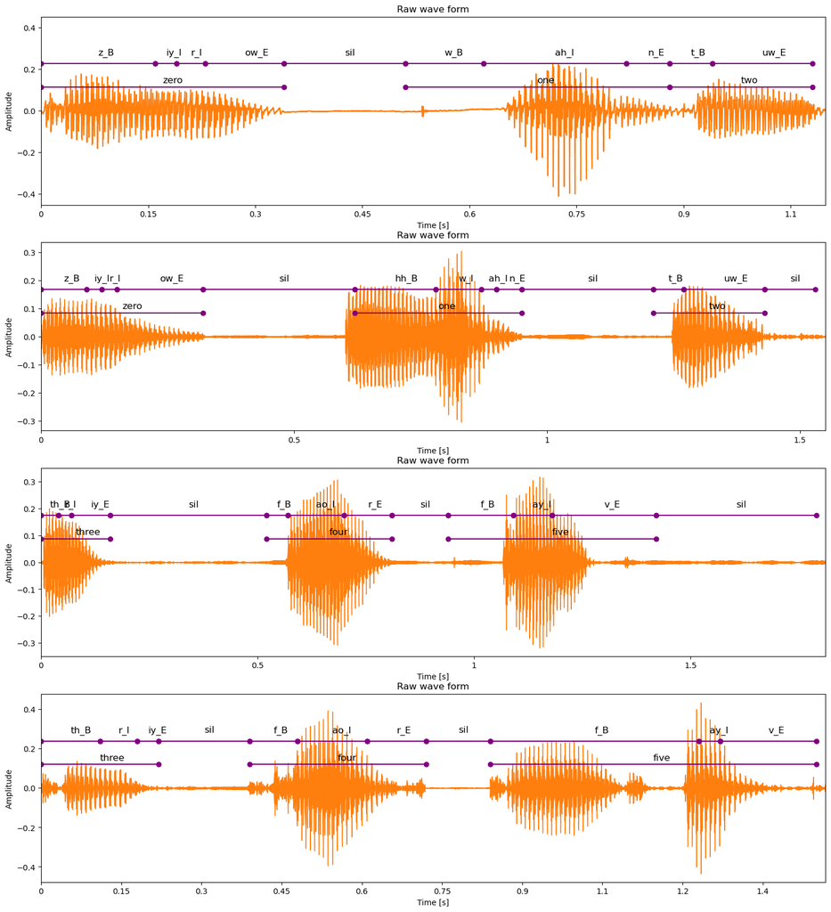

```python
plot_fig(
    (18, 20),
    [plot_raw_wave, plot_raw_wave, plot_raw_wave, plot_raw_wave],
    [{"df":df_files, "speaker":"s1", "audio_file":"0_1_2.wav", "model":"mono", "with_phones":True, "with_words":True},
    {"df":df_files, "speaker":"s2", "audio_file":"0_1_2.wav", "model":"mono", "with_phones":True, "with_words":True},
    {"df":df_files, "speaker":"s1", "audio_file":"3_4_5.wav", "model":"mono", "with_phones":True, "with_words":True},
    {"df":df_files, "speaker":"s2", "audio_file":"3_4_5.wav", "model":"mono", "with_phones":True, "with_words":True}]
)
```

> $s_{2}$ - `3_4_5.wav` (Depending on what you hear)

> | Actual | three four FOUR FIVE |
> | --- | --- |
> | ASR | three four FIVE ** |
> | Error | S D |

> Which gives $$WER=\frac{0+1+1}{4}\cdot 100\%= 50\%$$ and $$CER=\frac{0+3+4}{17}\cdot 100\%\approx 41.2\%$$

TRI1

Though the overall scoring of the MONO and TRI1 training are identical, this doesn't necessarily mean that their predicted transcription alignments are also the same. Especially since the TRI1 training further trains on the MONO alignments.

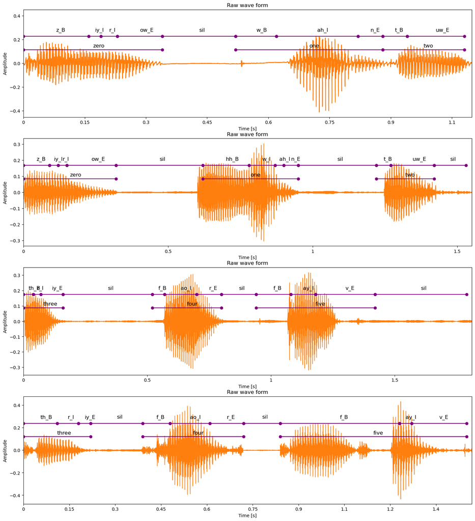

```python
plot_fig(
    (18,20),
    [plot_raw_wave, plot_raw_wave, plot_raw_wave, plot_raw_wave],
    [{"df":df_files, "speaker":"s1", "audio_file":"0_1_2.wav", "model":"tri1", "with_phones":True, "with_words":True},
    {"df":df_files, "speaker":"s2", "audio_file":"0_1_2.wav", "model":"tri1", "with_phones":True, "with_words":True},
    {"df":df_files, "speaker":"s1", "audio_file":"3_4_5.wav", "model":"tri1", "with_phones":True, "with_words":True},
    {"df":df_files, "speaker":"s2", "audio_file":"3_4_5.wav", "model":"tri1", "with_phones":True, "with_words":True}]
)
```

> Looking at these figures they are, to the naked eye, identical to those decoded using the MONO training. Only by looking at the files of the time marked transcription for TRI1 and MONO for both the words and phones are we able to see that there are minor differences in time alignment. Sine the MONO alignment was already very accurate on word level, the expectation that there could be even more improvement was limited. However, this does prove that even though the scores for both the MONO and TRI1 training are the same, they do recognize small differences in the time alignment.

## Step 10. Recognizing speech errors

To recognise the speech errors introduced by speakers $s_{1}$ and $s_{2}$ using the ASR models' probability scores we need to retrieve these. However, after doing more research in the framework of Kaldi as well as studying the answers given by one of Kaldi's makers on retrieving the acoustic or language models scores per frame or transcribed word or phone seems not possible or is possible, but would be a rough approximation with a rough work-around approach and not something you should want (1).

### Step 10.1 Time aligned transcription confidence scores

Otherwise obtained confidence scores calculated using the lattice-depth, word-categories, unigrams and the number of phones in a word for aligned phone and word lattices are computed.

MONO

```python
%%bash

# Generate the time aligned transcription on word level with confidence scores
./src/utils/generate_word_ctm_conf.sh mono
# Generate the time aligned transcription on phone level with confidence scores
./src/utils/generate_phone_ctm_conf.sh mono
```

[output not shown]

[output cut: 121 more lines]

[output not shown]

TRI1

```python
%%bash

# Generate the time aligned transcription on word level with confidence scores
./src/utils/generate_word_ctm_conf.sh tri1
# Generate the time aligned transcription on phone level with confidence scores
./src/utils/generate_phone_ctm_conf.sh tri1
```

[output not shown]

[output cut: 121 more lines]

[output not shown]

> Looking at these files it quickly becomes apparent that the confidence of each transcription is always 1. Looking at the LM this is not something you would immediately expect since:

```python
%%bash -s "$main_dir"

cd $1

fstdraw --portrait=true --isymbols=exp/tri1/graph/words.txt --osymbols=exp/tri1/graph/words.txt data/lang/G.fst | dot -Tsvg > G.svg
```

[figure not shown]

*(Since we now know that the MONO and TRI1 trained models both output the same confidence scores, we only show the lattices for the MONO trained model.)*

```python
%%bash -s "$main_dir"

cd $1
./utils/show_lattice.sh --mode save --format svg s1_6_7_8 exp/mono/decode/lat.1.gz data/lang/words.txt
./utils/show_lattice.sh --mode save --format svg s2_6_7_8 exp/mono/decode/lat.1.gz data/lang/words.txt
./utils/show_lattice.sh --mode save --format svg s1_9_0_1 exp/mono/decode/lat.1.gz data/lang/words.txt
./utils/show_lattice.sh --mode save --format svg s2_9_0_1 exp/mono/decode/lat.1.gz data/lang/words.txt
```

```
Saving to s1_6_7_8.svg
Saving to s2_6_7_8.svg
Saving to s1_9_0_1.svg
Saving to s2_9_0_1.svg
```

```
lattice-to-fst --lm-scale=0.0 --acoustic-scale=0.0 ark:- 'scp,p:echo s1_6_7_8 /tmp/kaldi.AZbU/s1_6_7_8.fst|'
LOG (lattice-to-fst[5.5.1057~1-be222]:main():lattice-to-fst.cc:89) Done converting 80 lattices to word-level FSTs
lattice-to-fst --lm-scale=0.0 --acoustic-scale=0.0 ark:- 'scp,p:echo s2_6_7_8 /tmp/kaldi.Weh7/s2_6_7_8.fst|'
LOG (lattice-to-fst[5.5.1057~1-be222]:main():lattice-to-fst.cc:89) Done converting 80 lattices to word-level FSTs
lattice-to-fst --lm-scale=0.0 --acoustic-scale=0.0 ark:- 'scp,p:echo s1_9_0_1 /tmp/kaldi.LWLP/s1_9_0_1.fst|'
LOG (lattice-to-fst[5.5.1057~1-be222]:main():lattice-to-fst.cc:89) Done converting 80 lattices to word-level FSTs
lattice-to-fst --lm-scale=0.0 --acoustic-scale=0.0 ark:- 'scp,p:echo s2_9_0_1 /tmp/kaldi.altf/s2_9_0_1.fst|'
LOG (lattice-to-fst[5.5.1057~1-be222]:main():lattice-to-fst.cc:89) Done converting 80 lattices to word-level FSTs
```

$S_{1}$ - [6 7 8]

[figure not shown]

In this picture we can also see the 'mistake' of the earlier shown sentence `6_3_1` where the 3 is deleted. This is caused by the best path found in the lattice of `6` is always followed by either 1 or 7.

$S_{2}$ - [6 7 8]

[figure not shown]

For this person the same situation. However, there is absolutely no other possibility that any other number than 8 follows after a `7`.

$S_{1}$ - [9 0 1]

[figure not shown]

$S_{2}$ - [9 0 1]

[figure not shown]

And for the other images again the lattices show always one optimal path, namely the only existing path. So for a confidence score consisting of among others the lattice depth and n-gram which in our case are both 1 results in a confidence score of 1.00

#### Conclusion

Because of the small dataset there are no competing paths for transcribing words resulting in a confidence score of 1. Therefore, for further research it is recommended to use a larger dataset. Another option could be to use an existing ASR model and research the confidence scores on an audio file with speech errors to determine whether a model trained fully on healthy speech can properly recognize broken speech. If the transcription results are bad, deciding to further train the model on broken speech could improve the model. Then, the original idea of this study can be implemented to research the possibility of using confidence scores for recognizing speech errors by for example setting a simple threshold.

### Step 10.2 Analysing speech errors

Besides trying to determine the differences in speech errors and normal speech using the confidence scores, we can also look at other attributes of the speech audio files. Such as the difference in vowel formants of speakers for the same words and their spectrograms.

#### Step 10.2.1 Vowel formants

Vowel formants, also known as formant (resonant) frequencies, are spikes in energy that show the vowel height, advancement and rounding over time. They are retrieved by looking at the highest spikes (somtimes a combination of 2 spikes) visible on the spectrum or by looking at the intensity of vowels on a spectrogram.

> > *Note* that in the `src.sample.get_formants()` function the bandwith is not considered when confirming a formant. This means that a rather large bandwidth (>400) is also considered to be a formant which can cause actual formants, much more clear in the spectrogram, to not be included or considered as for example F3/F4.

#### Step 10.2.2 Plots

To study different aspects of the audio files, the:

- raw wave (with predicted word and phone transcription),
- spectrogram (of full file),
- windowed samples (of time range),
- spectrum (with vowel formants of windowed samples),
- spectrogram (of time range with vowel formants)

will be used.

As examples we use the speaker $s_{1}$ and the utterance from `6_7_8.wav`.

```python
s1_678_samples = get_samples(df_files, "s1", "6_7_8.wav")
```

RAW WAVE

As shown earlier, the raw wave form of an audio signal shows at first sight whether there is sound at certain time intervals or not. We can use this to see if the \<SIL> phone has been correctly placed.

> > *Note* that this dataset contains almost no noise, and therefore the assumption can be made that the sound detected is always spoken sound. This is of course not applicable to data with noise.

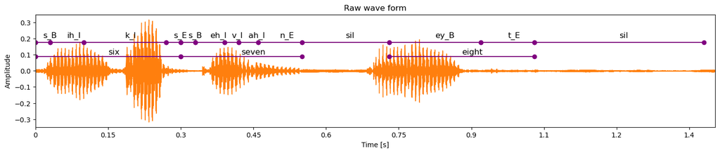

```python
fig, ax = plt.subplots(ncols=1, nrows=1, figsize=(18,3))
plot_raw_wave(
    df=df_files,
    speaker="s1",
    audio_file="6_7_8.wav",
    model="mono",
    ax=ax,
    with_phones=True,
    with_words=True)
```

[figure not shown]

This means that the alignment of the word six and thus seven is also very off.

SPECTROGRAM

A spectrogram as plotted here, is a representation of the Frequency in Hertz over time (s) of an audio signal. The closeness of bands in frequency show the intensity of the sound.

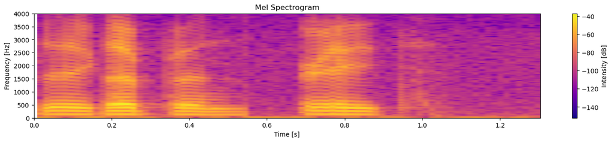

```python
fig, ax = plt.subplots(ncols=1, nrows=1, figsize=(18,3))
plot_spectrogram(
    samples=s1_678_samples,
    ax=ax,
    dt_0=.0,
    dt_end=get_time_samples(s1_678_samples)[-1] - 0.1,
    formants=False
    )
```

The confusion on where six ends and seven begins may have something to do with the relatively small moment of silence between [s ih k s] and [s eh p ah n] and probably also the common 's' sound. The other misalignment for the word 8 could be caused by the seemingly visible intentisity of some sound around t=0.95 but which is not quite high enough in intensity to actually mean something.

WINDOWED SAMPLE

Windowing is the act of cutting up audio into samples that partly overlap to get a stationary portion of a signal. This is done because the spectrum of audio is non-stationary: constantly changes over time. By extracting spectral features for MFCC vectors for example, this would cause the features to be a bad representation of the original signal.

However, because we work with speech audio we first apply a highpass filter to boost the amount of enery in the lower frequencies. For vowels there is often a lot of energy in the lower frequencies. By boosting these frequencies, the information of the formants for these vowels are more available to the acoustic model which in turn improves phone detecten accuracy.

For the range we look at the range [0.0 - 0.18], to fully focus on the word 6.

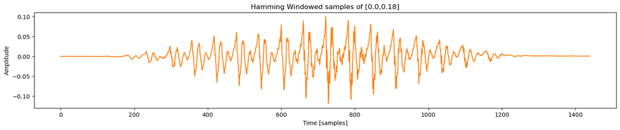

```python
fig, ax = plt.subplots(ncols=1, nrows=1, figsize=(18,3))
plot_windowed_samples(
    samples=s1_678_samples,
    ax=ax,
    dt_0=.0,
    dt_end=0.18
)
```

As we can see the signal of the range [.0, .18] has been evenly divided into an almost symmetrical signal, suggesting that the signal has come close to a stationary form. Looking very carefully however, at the first part [200, 600], it seems as though there is a slightly small portion of the signal that is slightly different from the rest of the windowed samples causing two curves to appear by only looking at the highest spikes in the Amplitude. This suggests that there may be some changes in the audio signal, that cause the non-stationary behaviour. Perhaps a change in phone as is to be expected from taking the audio of a six [s ih k s].

SPECTRUM

The spectrum is given by the Magnitude in decibels for the frequencies found in the windowed samples of a portion of the original audio signal.

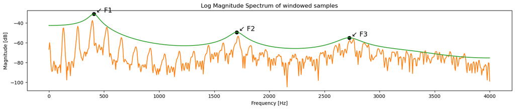

```python
fig, ax = plt.subplots(ncols=1, nrows=1, figsize=(18,3))
plot_magnitude_spectrum(
    samples=s1_678_samples,
    fig=fig,
    ax=ax,
    dt_0=.0,
    dt_end=.18,
    eps=0.028
)
```

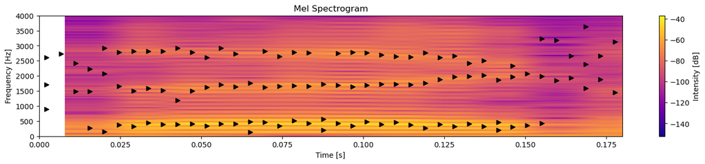

```python
fig, ax = plt.subplots(ncols=1, nrows=1, figsize=(18,3))
plot_spectrogram(
    samples=s1_678_samples,
    ax=ax,
    dt_0=.0,
    dt_end=.18,
    formants=True
)
```

As mentioned earlier, the formants are slightly off at some points, and when there is almost no sound, the formants are also not correct because there is nothing to make formants of. As we can see the formants at the end, around t=0.17, at least for the second and third formant are moving towards eachother. The second formant moves in an increasingly incremental way to just short of the third formant before stabilizing and fading out. This confirms the earlier found inconsistency in the signal.

INTERACTIVE PLOTS

Because comparing the common files of the speakers from the test set to those of the training set will be unreadable if each of these graphs are placed underneath eachother, interactive plots will be used for the common files to easily switch between speakers. Then, underneath the plot a sommation of the findings with screenshots of the most important findings will be showed.

RAW WAVE

Starting by comparing the common files for the speakers of the test set to those of the train set in terms of the raw wave form is the first step. From these wave files the timestamps of certain words and consonants will be used to later on dig deeper into the differences between the normally spoken words and the speech errors.

```python
@wg.interact(file=["0_1_2.wav", "3_4_5.wav", "6_7_8.wav", "9_0_1.wav"],
    speakers=df_files.index.get_level_values(0).unique(),
    model=["mono", "tri1"], phones=True, words=True)
def plot_interactive_raw_wave(file, speakers, model, phones, words):
    fig, ax = plt.subplots(ncols=1, nrows=1, figsize=(18,3))
    plot_raw_wave(df=df_files, speaker=speakers, audio_file=file,
        model=model, ax=ax, with_phones=phones, with_words=words)
    plt.show()
```

```
interactive(children=(Dropdown(description='file', options=('0_1_2.wav', '3_4_5.wav', '6_7_8.wav', '9_0_1.wav'…
```

So speaker $s_{1}$ makes the speech error on phone level, where the consonant /v/ is traded for a /p/, leading to five / f ay v / becoming fipe / f ay p / and seven / s eh v ah n / becoming / s eh p ah n /. As we have seen earlier however, the transcription does not include the changes in consonants because of the lack of data for alternative paths. Therefore, we use the consonant described as /v/ for the speaker $s_{1}$. This gives the following timestamps for the speakers: | | five | / f ay v / | seven | / s eh v ah n / | | :-- | :--: | :--: | :--: | :--: | | $s_{1}$ | 0.940-1.420 | 1.180-1.420 | 0.300-0.550 | 0.390-0.420 | | george | 0.900-1.470 | 1.160-1.470 | 0.490-1.230 | 0.670-0.830 | | jackson | 0.920-1.350 | 1.220-1.350 | 0.780-1.270 | 0.880-1.030 | | lucas | 1.120-1.620 | 1.360-1.620 | 0.460-1.150 | 0.840-0.930 | | nicolas | 0.610-0.960 | 0.860-0.960 | 0.200-0.550 | 0.300-0.440 | | theo | 0.500-0.800 | 0.750-0.800 | 0.580-0.930 | 0.690-0.800 | | yweweler | 0.770-1.080 | 1.030-1.080 | 0.280-0.770 | 0.410-0.550 |

> > *Note* that the MONO training was used for these timestamps, because of the small differences in alignments between the TRI1 and MONO training. Moreover, since the alignments are an approximation made by the ASR model there can be differences between the timestamps noted here for the alignment of phones and words and that of the actual alignment. This is further emphasized by the misalignment of the near silence belonging often to the alignment of that of words following or preceeding the near silence.

WINDOWED SIGNAL

As mentioned earlier, looking at the hamming windowed signal of a full word, will most likely result in the signal not becoming a stationary signal. This is caused by the different sounds being created within a single word caused by the different phones. So the primary focus will be the consonants of / v /.

```python
@wg.interact(file=["0_1_2.wav", "3_4_5.wav", "6_7_8.wav", "9_0_1.wav"],
    speakers=df_files.index.get_level_values(0).unique(),
    dt_0=(0.0, 3, 1e-3), dt_end=(0.0, 3, 1e-3))
def plot_interactive_win_signal(file, speakers, dt_0, dt_end):
    fig, ax = plt.subplots(ncols=1, nrows=1, figsize=(18,3))
    plot_windowed_samples(samples=get_samples(df_files, speakers, file), ax=ax, dt_0=dt_0, dt_end=dt_end)
    plt.show()
```

```
interactive(children=(Dropdown(description='file', options=('0_1_2.wav', '3_4_5.wav', '6_7_8.wav', '9_0_1.wav'…
```

From the hamming windowed samples of $s_{1}$ for the consonant / v / in five, we can see that there is no symmetry at all. Which means that this signal part is very non-stationary. Comparing this to the other speakers, the speakers 'George', 'Jackson', 'Lucas' are also very non-stationary whereas the speaker 'Nicolas' has a a much more clear symmetric windowed signal and are the signals of 'Theo' and 'Yweweler' also approaching a more stationary signal. Concluding anything on whether it is because of the misalignment, pronounciation or just length in duration used for windowing are all possible causes, but can not be proved because of the lack of data. The dataset consists of multiple dialects each one not appearing more than a handfull of times which makes proving the dialect as a factor an impossible task. The misalignment is also hard to prove, since the lack of linguistic background to correctly define when each phone/word starts and ends is missing. And lack of duration is plausible, however the smaller the windows are taken the less likely a window is to contain any context about surrounding windows. Usually windows of 25 ms are taken with a 10 ms overlaying shift. So it could be that this greatly affects the windowed signal of the very non-stationary signals. But, creating windows using a constant timeframe and timeshift doesn't mean that each window can only contain one phone. It is highly more likely for phones to last multiple frames. So, it may also just be that the pronunciation of a certain phone quickly changes over time causing the non-stationary behaviour. Or more than one phone was taken in with the sampled signal for windowing.

For the hamming windowed samples of the consonant / v / in seven for the test speaker, we can see that what happens when a window is taken from a time frame which in itself would normally create a window. Namely, the oversimplification of an audio signal which in this case makes the windowed signal approach a symmetric form. The speakers from the train set, however, all seem to become rather symmetrical with Theo and Yweweler in the lead.

SPECTRUM

Though the spectrum for non-stationary signals is not very interesting, let alone the signal of a word, it could for the consonant / v / in seven maybe show some insight into the different pitches used to create the consonant.

```python
@wg.interact(file=["0_1_2.wav", "3_4_5.wav", "6_7_8.wav", "9_0_1.wav"],
    speakers=df_files.index.get_level_values(0).unique(),
    dt_0=(0.0, 2, 1e-3), dt_end=(0.0, 3, 1e-3), eps=(.0, 1e3, 1e-2))
def plot_interactive_win_signal(file, speakers, dt_0, dt_end, eps):
    fig, ax = plt.subplots(ncols=1, nrows=1, figsize=(18,3))
    plot_magnitude_spectrum(samples=get_samples(df_files, speakers, file), fig=fig, ax=ax, dt_0=dt_0, dt_end=dt_end, eps=eps)
    plt.show()
```

```
interactive(children=(Dropdown(description='file', options=('0_1_2.wav', '3_4_5.wav', '6_7_8.wav', '9_0_1.wav'…
```

As mentioned before on the time range for the speaker $s_{1}$ on the consonant / v / which is very small and the possible consequences of that, we can clearly see that in the magnitude spectrum. The peaks are very wide indicating that the information within the used time frame is on the small side. The First formant lies seemingly on 500Hz, the second around 1500Hz and the third formant around 2600Hz. Retrieving this for the other speakers, gives the following information:

|  | F1 | F2 | F3 |
| --- | --- | --- | --- |
| $s_{1}$ | 500 | 1500 | 2600 |
| george | 500 | 1750 | 3400 |
| jackson | 500 | 1700 | 3400 |
| lucas | 500 | 1500 | 2450 |
| nicolas | 500 | 1750 | 2800 |
| theo | 550 | 1600 | 2500 |
| yweweler | 500 | 1600 | 2750 |

SPECTROGRAM

Looking at the spectrograms with the formants drawn in them for both the words and phones can provide insight into the movement of sound for vowels and consonants within words. Though the formants lay near eachother, within this small time frame it does not necessarily mean that this generalization holds for the full signal that is windowed.

```python
@wg.interact(file=["0_1_2.wav", "3_4_5.wav", "6_7_8.wav", "9_0_1.wav"],
    speakers=df_files.index.get_level_values(0).unique(),
    dt_0=(0.0, 2, 1e-3), dt_end=(0.0, 3, 1e-3), formants=True)
def plot_interactive_win_signal(file, speakers, dt_0, dt_end, formants):
    fig, ax = plt.subplots(ncols=1, nrows=1, figsize=(18,3))
    plot_spectrogram(samples=get_samples(df_files, speakers, file), ax=ax,
    dt_0=dt_0, dt_end=dt_end, formants=formants
    )
    plt.show()
```

```
interactive(children=(Dropdown(description='file', options=('0_1_2.wav', '3_4_5.wav', '6_7_8.wav', '9_0_1.wav'…
```

Starting with where we left of for the speaker $s_{1}$. If we zoom in on the digit seven for this speaker and then in specific the consonant / v /, we see that the first and second formant are rather constant whereas the third formant seems to slowly increment before fading out. Looking at the spectrogram of george the first thing that shows is the overall high intensity of the sound in contrast to that of $s_{1}$ as well as the many narrow bands. For the speaker jackson the bands are wider. The formants however with the exception of the second formant are not very steady. Especially zooming in on the consonant. Looking at the break in the third formant which is included in the alignment for the consonant makes it highly likely that the alignment is incorrect. Formants fading in and out during a phone is not out of the ordinary, but having a formant dissapear for a duration of time only to reappear for the same phone is not really believable. This again shows that the alignments approach the actual alignments, but don't always do a good job of starting or ending at the right moment.

Moving on to speaker $s_{2}$ and the digit 9, while keeping in mind that

[figure not shown]

the approximation made by the ASR model includes both near silence and a portion of the next digit it is easily explainable why we seem to see three words. When looking at the spectrogram it is more likely that the digit 9 ends around 0.34s from looking at the intensity and fading formants. For this speaker the blend speech error looks more like two seperate words, which would make using this as information for recognizing speech errors very challenging if you did not know that that wasn't supposed to be there. Looking at the speaker yweweler, we see that this speaker also has very narrow bands and his alignment also includes a lot of near silence at the end. From the form of the second and third formant creating an open space because of the first and second formant meeting eachother we can see that the sound made here is in the lower vowel space. After the vowel in nine is formed it seemingly opens again to form the sound of the consonant n before fading. Which is a contrast to formants of the speaker jackson where the band are both wider and more seperated and very constant over time. Again, this could be caused by the difference in pronunciation, but the data is too small to draw such a definite conclusion.

#### Conclusion

The overall conclusion of recognizing speech errors using this approach seems to be that the dataset is too varied in dialects as well as too small to accurately determine or exclude cases to form a vast conclusion on whether a speech error was really found or the differences found are just the cause of differently used mic's or dialects. Therefore, there is no real conclusion on finding speech errors using this type of analysis, but rather the advice to enlarge the dataset using speakers whose mother language corresponds to the language targeted. And, cutting the audio files using some constant time value results in audio being cut between utterances and on utterances resulting in vague sounds appearing. Rather, using a full sentence based audio is more natural and perhaps would lead to more realistic conclusions in findings as opposed to concatenated files that may not have been connected properly resulting in long silences or peaks in sounds.

Perhaps a better approach to the problem of recognising speech errors is to start by focusing on recognising one type of speech error. And from there, use the results to move on to trying to use the same method for recognising other speech errors.

Another problem is that recognising these errors by eye is very biased in the sense that we know where they occur, so the focus in this research was heavily on the part where the speech error occured. During conversations with the supervisor and listening to actual conversations of aphasic patients it is highly more likely that moments where a speech error occurs can be recognized not by that moment but rather by the sounds made before the speech error or the sounds made after the speech errors.